# Visualization Essay: Exploratory Data Analysis

Laura Crossley

3/21/2017

As shown in the below graph of New York’s U.S. House of Representatives elections, Federalists took the lead in vote percentages in almost every year through 1800, after which they were overtaken by the Republicans. This shift in power fits the national trend of the Federalist Party losing power beginning with John Adams’(Federalist) loss to Thomas Jefferson (Democratic-Republican) in the 1800 U.S. presidential election. Although the 1808 elections were close in vote percentages, New York’s Federalists did not take the lead over Republicans again until 1812. This reflects the gains made by the party through their opposition to the War of 1812. The party’s successes in New York were clearly short-lived, however, as they did not overtake the Republicans again before the party was dissolved in 1824.

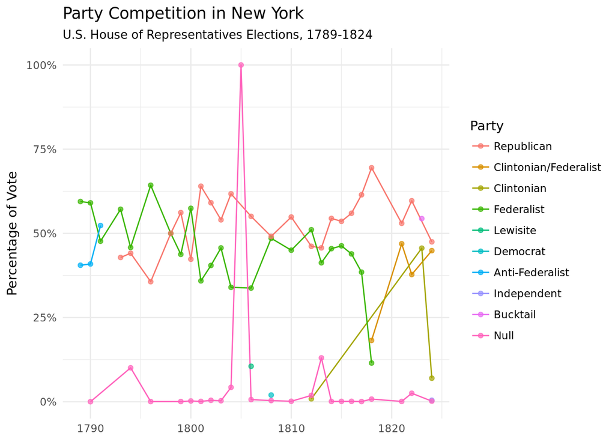